# CS_Project

Author

Claudia Salerno

## Introduction

Pediatric dentistry plays a pivotal role in ensuring the oral health and well-being of children, starting from infancy through adolescence. Early intervention and education are paramount in preventing oral diseases and establishing healthy dental habits that can last a lifetime. While both dentists and pediatricians are integral members of the healthcare team for children, their roles, expertise, approaches and timing to pediatric oral health may differ. The aim of this paper is to compare the knowledge, attitudes, and practices regarding pediatric dentistry between dentists and pediatricians. By examining the perspectives of these two healthcare professionals, we seek to identify potential areas of collaboration, opportunities for interdisciplinary education, and strategies for improving pediatric oral health outcomes.

Understanding the similarities and differences in knowledge and practices between dentists and pediatricians is crucial for developing comprehensive and integrated approaches to pediatric dental care. By elucidating the strengths and challenges within each profession, we can enhance communication, coordination, and referral pathways to ensure optimal oral health outcomes for children. Moreover, addressing any gaps in knowledge or misconceptions may lead to more effective preventive measures and early interventions, ultimately reducing the burden of oral diseases in pediatric populations.

Therefore, the aim is to contribute to the advancement of pediatric dental care and the promotion of interdisciplinary collaboration between dentists and pediatricians understanging the knwoledge gap on oral health between these two mediacl figures.

## Materials and Methods

A web-based questionnaire was created and distributed online to pediatricians and dentists who decided to take a course on pediatric dentistry. The questionnaire could be fulfilled before the course start.

## Results

```r
library(ggplot2)
library(readxl)
library (readr)
library (here)
```

```
here() starts at /Users/claudiasalerno/Desktop/R/dent_ped
```

```r
original_dataset <- read_xlsx(here("data", "raw", "doctor.xlsx"))  # Assicurati di sostituire "nome_del_tuo_file.csv" con il percorso corretto del tuo file

# Filtra le righe dove "di quale disciplina ti occupi" è "pediatria" e seleziona solo le prime 18 colonne
new_dataset <- subset(original_dataset, select = 1:5)

# Stampa il nuovo dataset
print(new_dataset)
```

```
# A tibble: 481 × 5
   `Response number` disciplina             work_experience dent_decidui_age
   <chr>             <chr>                  <chr>           <chr>
 1 1                 Pediatria              Da 11 a 15 anni 6-12 mesi
 2 10                Pediatria              Più di 20 anni  6-12 mesi
 3 100               Pediatria              Più di 20 anni  6-12 mesi
 4 101               Pediatria              Più di 20 anni  6-12 mesi
 5 102               Altra specializzazione Più di 20 anni  6-12 mesi
 6 103               Pediatria              Più di 20 anni  6-12 mesi
 7 104               Pediatria              Da 11 a 15 anni 6-12 mesi
 8 105               Pediatria              Più di 20 anni  <NA>
 9 106               Altra specializzazione Da 16 a 20 anni 6-12 mesi
10 107               Altra specializzazione Da 11 a 15 anni 6-12 mesi
# ℹ 471 more rows
# ℹ 1 more variable: dent_decidui_numb <chr>
```

Figure 1 explores the type of doctors that answered to the questionnaire.

Figure 2 explores years of experience for each type of doctors that answered to the questionnaire.

Figure 3 explores doctors’ knowledge on the correct number of primary teeth

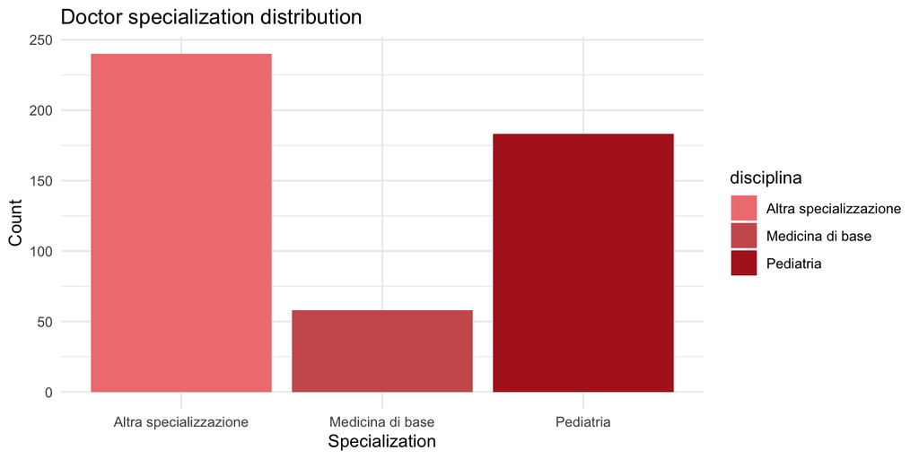

Figure 1: Type of doctors.

```r
ggplot(data = new_dataset, aes(x = disciplina, fill = disciplina)) +
geom_bar() + labs(title = "Doctor specialization distribution",
x = "Specialization",
y = "Count") +
scale_fill_manual(values = c("lightcoral", "indianred", "firebrick", "darkred")) + theme_minimal()
```

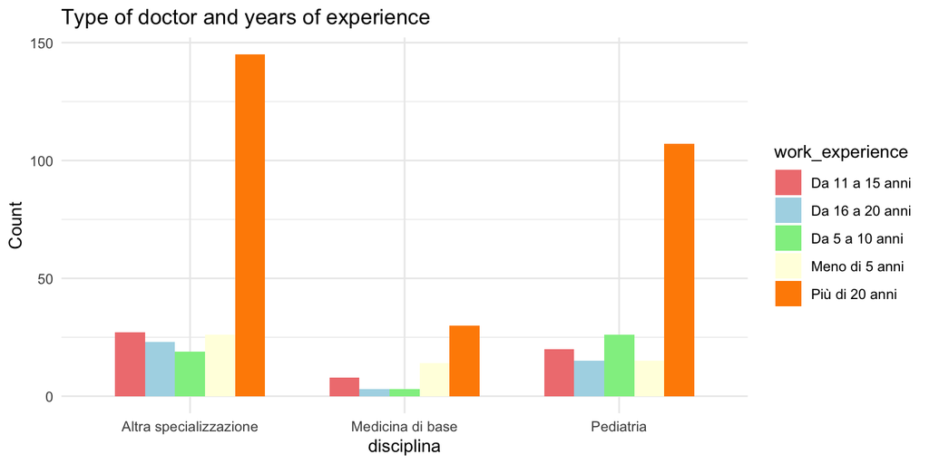

Figure 2: Work experience for each type of doctor.

```r
ggplot(data = new_dataset, aes(x = disciplina, fill = work_experience)) +
  geom_bar(position = "dodge", width = 0.7) +
  labs(title = "Type of doctor and years of experience",
       x = "disciplina",
       y = "Count") +
  scale_fill_manual(values = c("lightcoral", "lightblue", "lightgreen", "lightyellow", "darkorange")) +  # Specifica i colori per le risposte alla variabile 2
  theme_minimal()
```

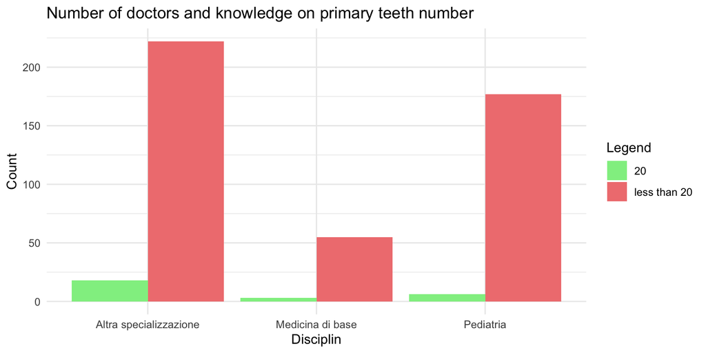

Figure 3: Number of primary teeth knowledge for each type of doctor.

```r
ggplot(data = new_dataset, aes(x = disciplina, fill = factor(dent_decidui_numb <= 20))) +
  geom_bar(position = "dodge") +
  labs(title = "Number of doctors and knowledge on primary teeth number",
       x = "Disciplin",
       y = "Count",
       fill= "Legend") +
  scale_fill_manual(values = c("lightgreen", "lightcoral"),
                    labels = c("20", "less than 20")) +  # Etichette per i colori
  theme_minimal()
```